# Accessing the National Weather Service API

To access the National Weather Service (NWS) API in R, we need to send HTTP requests to the API’s endpoints. Here (.qmd) template for a document that includes R code to access the NWS API, specifically for obtaining weather data such as temperature, precipitation, and weather conditions.

1. API URL: https://api.weather.gov.
2. User-Agent Requirement: The national weather service API requires a User-Agent header in the request. Include email or another identifier.

# Accessing the NWS API

In this vignette, we will display the weather forecast of New York City and extract the data and make ggplot using tidyverse and httr package.

I have retrieve and visualizes weather alerts for New York City from the National Weather Service (NWS) API. The purpose is to monitor latest alerts, such as warnings or servere weather notifications. This API provides real-time weather alerts for NYC.

I have used the httr2 package to access NWS alerts for New York City.

```r
# Define the API endpoint for NYC alerts
nws_request <- request("https://api.weather.gov/alerts/active") %>%
  req_url_query(area = "NY") # `area` is set to "NY" to filter for New York alerts

# Perform the request and parse JSON response
nws_alerts <- nws_request %>%
  req_perform() %>%
  resp_body_json()

# Extract alerts as a tibble
alerts_df <- tibble(
  event = map_chr(nws_alerts$features, list("properties", "event")),
  headline = map_chr(nws_alerts$features, list("properties", "headline")),
  description = map_chr(nws_alerts$features, list("properties", "description")),
  severity = map_chr(nws_alerts$features, list("properties", "severity")),
  effective = map_chr(nws_alerts$features, list("properties", "effective")),
  expires = map_chr(nws_alerts$features, list("properties", "expires"))
)

# Display the first few alerts
head(alerts_df)
```

```
# A tibble: 1 × 6
  event         headline                  description severity effective expires
  <chr>         <chr>                     <chr>       <chr>    <chr>     <chr>
1 Wind Advisory Wind Advisory issued Dec… "* WHAT...… Moderate 2024-12-… 2024-1…
```

# Visualizing Alert Weather Data

# Timeline of Alerts by Severity

To visualize when each alert is active, we can create a timeline plot where each alert is represented as a point, colored by its severity.

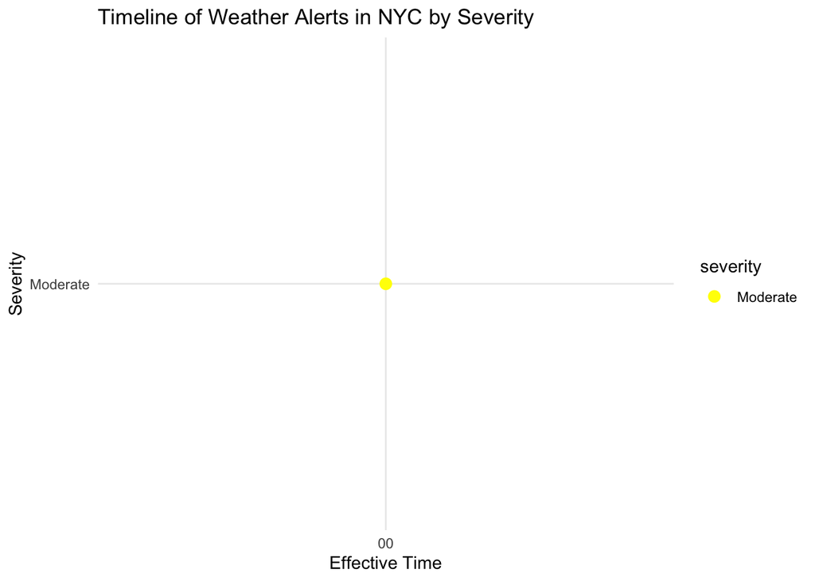

```r
# Convert `effective` and `expires` columns to POSIXct for proper time handling
alerts_df <- alerts_df %>%
  mutate(
    effective = as.POSIXct(effective),
    expires = as.POSIXct(expires)
  )

# Plot timeline of alerts
ggplot(alerts_df, aes(x = effective, y = severity, color = severity)) +
  geom_point(size = 3) +
  labs(title = "Timeline of Weather Alerts in NYC by Severity",
       x = "Effective Time",
       y = "Severity") +
  scale_color_manual(values = c("Minor" = "green", "Moderate" = "yellow", "Severe" = "red", "Extreme" = "darkred")) +
  theme_minimal()
```

# Horizontal Bar Plot for Alerts by Type

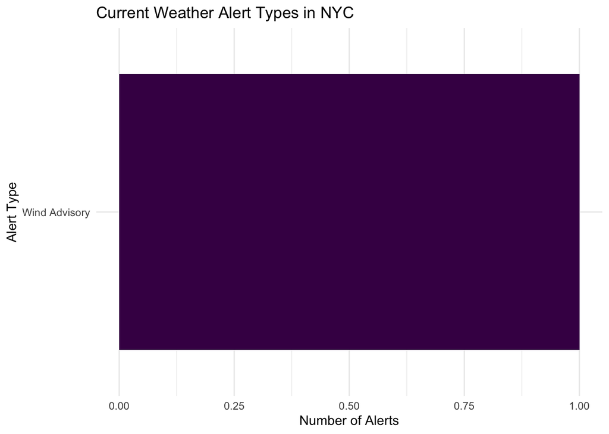

```r
# Count and plot the types of alerts
alerts_df %>%
  count(event) %>%
  ggplot(aes(x = n, y = reorder(event, n), fill = event)) +
  geom_bar(stat = "identity") +
  labs(title = "Current Weather Alert Types in NYC",
       x = "Number of Alerts",
       y = "Alert Type") +
  scale_fill_viridis_d() +  # Optional: color palette for clarity
  theme_minimal() +
  theme(legend.position = "none")
```

# Timeline plot with Start and End times for alert

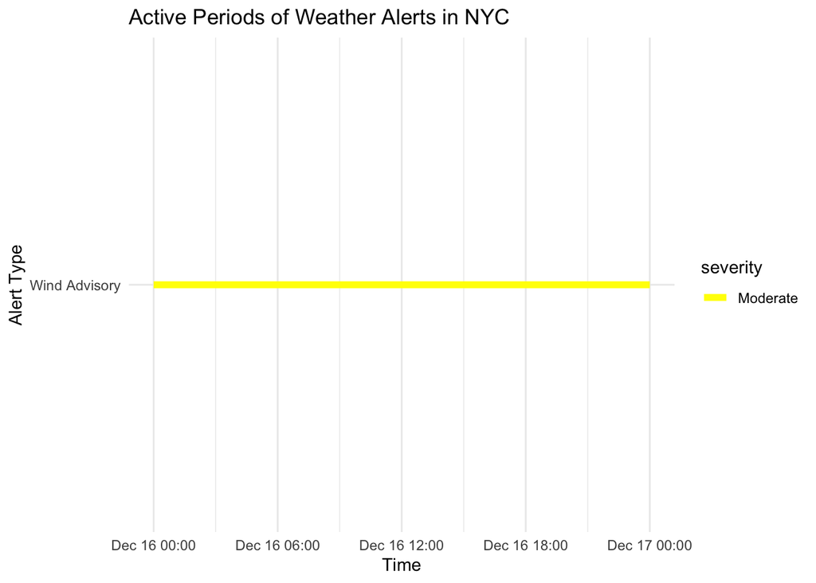

```r
# Timeline plot with start and end times
ggplot(alerts_df, aes(x = effective, xend = expires, y = event, color = severity)) +
  geom_segment(size = 2) +
  labs(title = "Active Periods of Weather Alerts in NYC",
       x = "Time",
       y = "Alert Type") +
  scale_color_manual(values = c("Minor" = "green", "Moderate" = "yellow", "Severe" = "red", "Extreme" = "darkred")) +
  theme_minimal()
```

# Conclusion

This analysis provides an overview of current weather alerts for New York City. Severe weather alerts can be critical for residents and local authorities to take preventive measures. This method can be automated to regularly check for new alerts, making it a valuable tool for real-time weather monitoring.

# Extension: Curtis Elsasser, 11/22/2024

I would like to extend Rupendra’s excellent work with a forecast. They pair nicely with alerts. A peek around the corner to see what is coming. Reassurance that the earth will still be spinning tomorrow and that we will be on its surface. I was going to add a forecast for the next 7 days, but the data is not very nice so I’m pivoting to an hourly forecast. Which, just so happens to also be 7 days of data. I think this is going to be interesting, especially since I am writing this in the midst of a storm for which the NWS has posted a “Winter Storm Warning” alert. It will be interesting to see how closely the forecast parallels the actual weather, hour by hour.

## Support

```r
# The heart of Sheep Meadow
latitude <- 40.7718
longitude <- -73.9796
nws_points_url <- str_c("https://api.weather.gov/points/", latitude, ",", longitude)
```

## Get the Forecast

First step is to translate our coordinates into a blocked request URL. The weather service makes forecasts based on a grid. We need to let NWS figure out which grid or block our coordinates are in. In that response will be a URL with which we may request the forecast from the NWS API.

```r
points_json <- request(nws_points_url) |>
  req_perform() |>
  resp_body_json()

nws_forecast_url <- points_json$properties$forecast
nws_hourly_url <- points_json$properties$forecastHourly
forecast_json <- request(nws_hourly_url) |>
  req_perform() |>
  resp_body_json()
```

## Parse the Forecast

```r
forecast_tbl <- tibble(json = forecast_json$properties$periods) |>
  unnest_wider(json) |>
  unnest_wider(probabilityOfPrecipitation, names_sep = "_") |>
  unnest_wider(dewpoint, names_sep = "_") |>
  unnest_wider(relativeHumidity, names_sep = "_") |>
  mutate(
    startTime = as_datetime(startTime),
    endTime = as_datetime(endTime)
  )
forecast_tbl
```

```
# A tibble: 156 × 19
   number name  startTime           endTime             isDaytime temperature
    <int> <chr> <dttm>              <dttm>              <lgl>           <int>
 1      1 ""    2024-12-16 15:00:00 2024-12-16 16:00:00 TRUE               44
 2      2 ""    2024-12-16 16:00:00 2024-12-16 17:00:00 TRUE               45
 3      3 ""    2024-12-16 17:00:00 2024-12-16 18:00:00 TRUE               44
 4      4 ""    2024-12-16 18:00:00 2024-12-16 19:00:00 TRUE               44
 5      5 ""    2024-12-16 19:00:00 2024-12-16 20:00:00 TRUE               45
 6      6 ""    2024-12-16 20:00:00 2024-12-16 21:00:00 TRUE               45
 7      7 ""    2024-12-16 21:00:00 2024-12-16 22:00:00 TRUE               46
 8      8 ""    2024-12-16 22:00:00 2024-12-16 23:00:00 TRUE               46
 9      9 ""    2024-12-16 23:00:00 2024-12-17 00:00:00 FALSE              47
10     10 ""    2024-12-17 00:00:00 2024-12-17 01:00:00 FALSE              48
# ℹ 146 more rows
# ℹ 13 more variables: temperatureUnit <chr>, temperatureTrend <chr>,
#   probabilityOfPrecipitation_unitCode <chr>,
#   probabilityOfPrecipitation_value <int>, dewpoint_unitCode <chr>,
#   dewpoint_value <dbl>, relativeHumidity_unitCode <chr>,
#   relativeHumidity_value <int>, windSpeed <chr>, windDirection <chr>,
#   icon <chr>, shortForecast <chr>, detailedForecast <chr>
```

## Visualize the Forecast

### Temperature

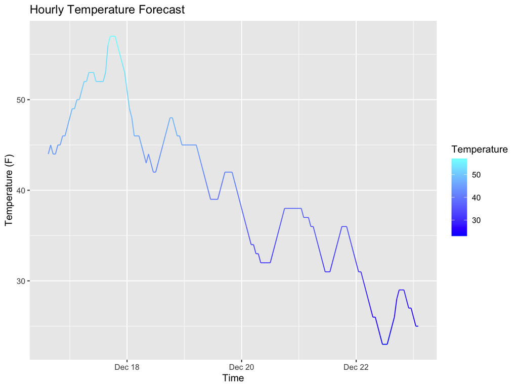

```r
forecast_tbl |>
  ggplot(mapping = aes(
    x = startTime,
    y = temperature,
    color = temperature
  )) +
  geom_line() +
  # Mr. Freeze Meiser color scheme. It is 11/22 after all.
  scale_color_gradient(low = "#0000ff", high = "#80ffff", name = "Temperature") +
  labs(
    title = "Hourly Temperature Forecast",
    x = "Time",
    y = "Temperature (F)"
  )
```

### Precipitation

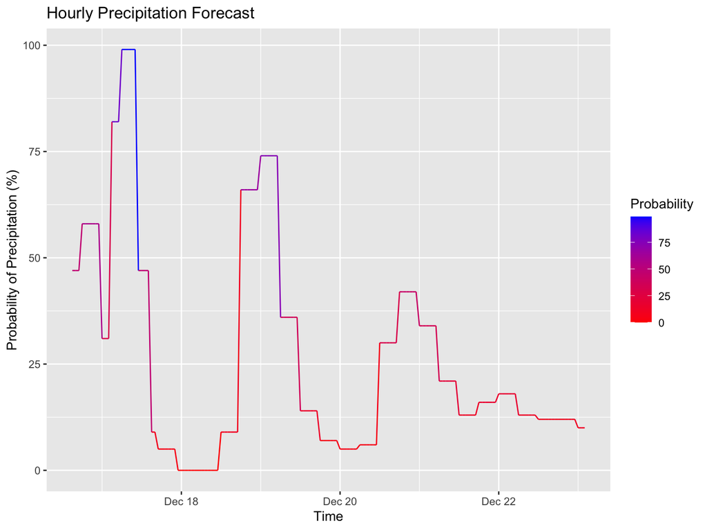

```r
forecast_tbl |>
  ggplot(mapping = aes(
    x = startTime,
    y = probabilityOfPrecipitation_value,
    color = probabilityOfPrecipitation_value
  )) +
  geom_line() +
  scale_color_gradient(low = "red", high = "blue", name = "Probability") +
  labs(
    title = "Hourly Precipitation Forecast",
    x = "Time",
    y = "Probability of Precipitation (%)"
  )
```

### Just for Fun

Let’s see how they are distributed. This may be a nonsense task, but I am curious.

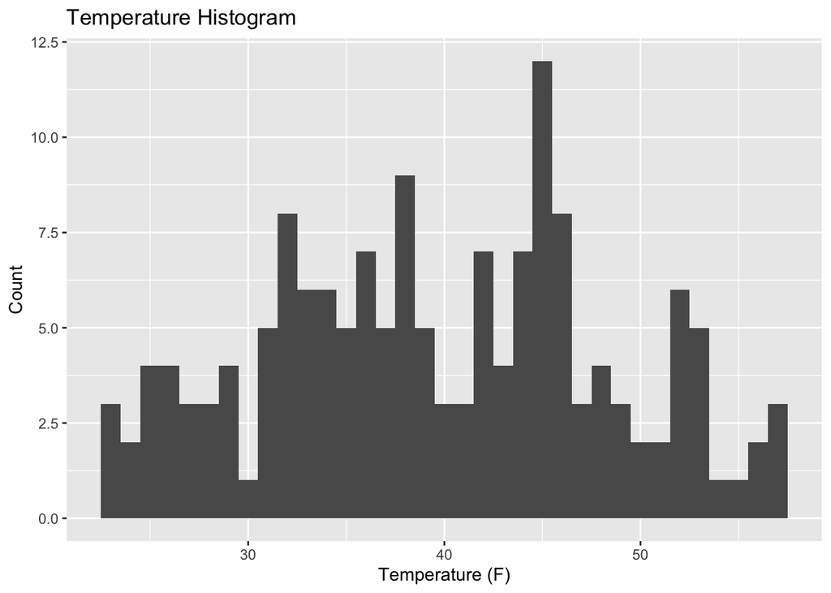

```r
forecast_tbl |>
  ggplot(mapping = aes(x = temperature)) +
  geom_histogram(binwidth = 1) +
  labs(
    title = "Temperature Histogram",
    x = "Temperature (F)",
    y = "Count"
  )
```

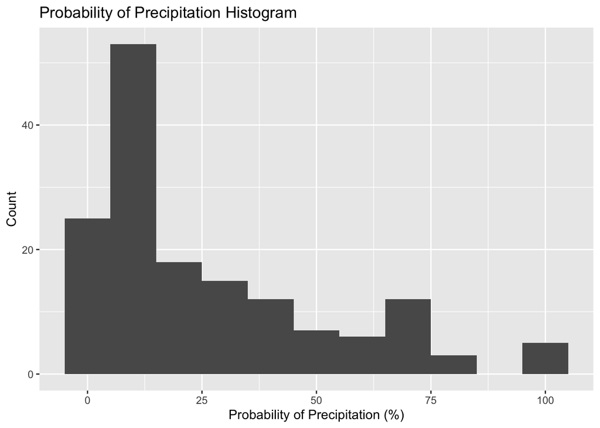

```r
forecast_tbl |>
  ggplot(mapping = aes(x = probabilityOfPrecipitation_value)) +
  geom_histogram(binwidth = 10) +
  labs(
    title = "Probability of Precipitation Histogram",
    x = "Probability of Precipitation (%)",
    y = "Count"
  )
```

### Extended Data

I choose to visuallize the dewpints at hourly rate and windspeed mph in hourly rate.

[figure not shown]

```r
# Dew Point Temperature Visualization
forecast_tbl |>
  ggplot(mapping = aes(
    x = startTime,
    y = dewpoint_value,
    color = dewpoint_value
  )) +
  geom_line() +
  scale_color_gradient(low = "#654321", high = "#f4a460", name = "Dew Point (°F)") +
  labs(
    title = "Hourly Dew Point Forecast",
    x = "Time",
    y = "Dew Point (°F)"
  ) +
  theme_minimal()
```

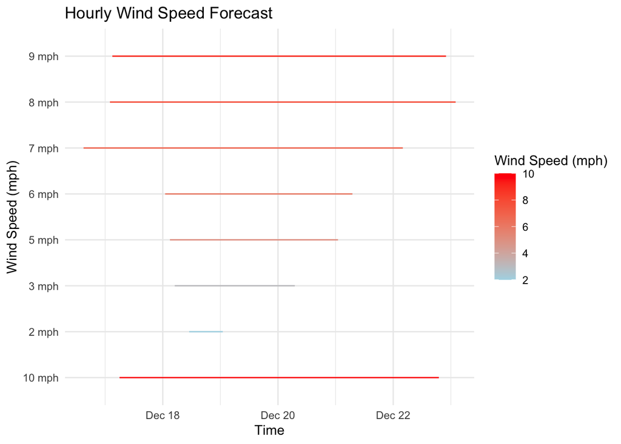

```r
# Wind Speed Visualization
forecast_tbl |>
  ggplot(mapping = aes(
    x = startTime,
    y = windSpeed,
    color = as.numeric(str_extract(windSpeed, "\\d+"))
  )) +
  geom_line() +
  scale_color_gradient(low = "lightblue", high = "red", name = "Wind Speed (mph)") +
  labs(
    title = "Hourly Wind Speed Forecast",
    x = "Time",
    y = "Wind Speed (mph)"
  ) +
  theme_minimal()
```

## Conclusion

It was fun extending Rupendra’s work and I think it was a fruitful collaboration. We now have alerts and the ability to look around the corner and see what the NWS thinks is coming.